# Objective 4: Behavioral Mediators

Standalone analytical report

Published

May 25, 2026

## 1 Report Purpose

This standalone analytical report records the current Objective 4 pathway-screening evidence. It is not a manuscript. Its purpose is to show how youth-informed pathway domains, measured adolescent variables, upstream exposure-pathway associations, downstream pathway-outcome associations, and fixed-covariate sensitivity checks support mediator prioritisation.

This report uses the refreshed pathway-screening release bundle, including the extended strict trajectory screening outputs and the nested fixed-covariate review. The Objective 4 website page should be checked against this report rather than against older screening figures.

## 2 Source Files

|  | Source file | Modified |
| --- | --- | --- |
| results/pathway_screening/tables/run_manifest.csv | results/pathway_screening/tables/run_manifest.csv | 2026-05-25 14:35:40 SAST |
| results/pathway_screening/tables/transition_path_screening_manifest.csv | results/pathway_screening/tables/transition_path_screening_manifest.csv | 2026-05-25 14:35:40 SAST |
| results/pathway_screening/tables/contextual_pathway_inventory_summary.csv | results/pathway_screening/tables/contextual_pathway_inventory_summary.csv | 2026-05-25 14:35:40 SAST |
| results/pathway_screening/tables/contextual_pathway_inventory_long.csv | results/pathway_screening/tables/contextual_pathway_inventory_long.csv | 2026-05-25 14:35:40 SAST |
| results/pathway_screening/tables/nested_b_path_driver_summary.csv | results/pathway_screening/tables/nested_b_path_driver_summary.csv | 2026-05-25 14:35:40 SAST |
| results/pathway_screening/tables/nested_b_path_comparison.csv | results/pathway_screening/tables/nested_b_path_comparison.csv | 2026-05-25 14:35:40 SAST |
| results/pathway_screening/tables/nested_b_path_covariate_vif.csv | results/pathway_screening/tables/nested_b_path_covariate_vif.csv | 2026-05-25 14:35:40 SAST |
| results/pathway_screening/tables/pathway_variable_coverage.csv | results/pathway_screening/tables/pathway_variable_coverage.csv | 2026-05-25 14:35:40 SAST |
| results/pathway_screening/tables/transition_path_a_hypothesis_coefficients_all_models.csv | results/pathway_screening/tables/transition_path_a_hypothesis_coefficients_all_models.csv | 2026-05-25 14:35:40 SAST |
| results/pathway_screening/tables/transition_path_b_coefficients_all_models.csv | results/pathway_screening/tables/transition_path_b_coefficients_all_models.csv | 2026-05-25 14:35:40 SAST |
| results/pathway_screening/tables/draw_level_effective_sample_size.csv | results/pathway_screening/tables/draw_level_effective_sample_size.csv | 2026-05-25 14:35:40 SAST |
| results/pathway_screening/tables/ulwom_primary_vs_twowindow_bch_comparison.csv | results/pathway_screening/tables/ulwom_primary_vs_twowindow_bch_comparison.csv | 2026-05-25 14:35:40 SAST |
| results/pathway_screening/tables/ulwom_primary_vs_twowindow_bch_comparison_diagnostic.csv | results/pathway_screening/tables/ulwom_primary_vs_twowindow_bch_comparison_diagnostic.csv | 2026-05-25 14:35:40 SAST |
| results/pathway_screening/figures/transition_pathway_publication_summary.png | results/pathway_screening/figures/transition_pathway_publication_summary.png | 2026-05-25 14:35:40 SAST |
| results/pathway_screening/figures/transition_pathway_evidence_map.png | results/pathway_screening/figures/transition_pathway_evidence_map.png | 2026-05-25 14:35:40 SAST |
| results/pathway_screening/figures/manuscript_screening_framework.svg | results/pathway_screening/figures/manuscript_screening_framework.svg | 2026-05-25 14:35:40 SAST |
| results/pathway_screening/figures/interaction_pathway_publication_summary.png | results/pathway_screening/figures/interaction_pathway_publication_summary.png | 2026-05-25 14:35:40 SAST |
| results/pathway_screening/figures/nested_fixed_covariate_b_path_review.png | results/pathway_screening/figures/nested_fixed_covariate_b_path_review.png | 2026-05-25 14:35:40 SAST |

## 3 SAP Alignment

Objective 4 screens adolescent pathway domains before formal causal mediation. The SAP requires this stage to identify which pathway domains are coherent enough, sufficiently represented in the harmonized data, and empirically supported enough to carry into Objective 5.

The retained screening family is anchored in childhood trajectory histories from Objective 3 and the harmonized depressive-symptom endpoint from Objective 2.

## 4 Release Run Status

| Run timestamp | Models requested | Models completed | Posterior draw range | Upstream pooled rows | Downstream pooled rows | Canonical mediators detected |
| --- | --- | --- | --- | --- | --- | --- |
| 2026-03-31 17:55:57 | maternal co-residence, paternal co-residence, household socioeconomic status, joint parental residence, joint parental residence and household socioeconomic status | joint parental residence, joint parental residence and household socioeconomic status, household socioeconomic status, paternal co-residence, maternal co-residence | 1-100 | 287 | 35 | alcohol use, ever had sexual intercourse, food insecurity, lack of government grant receipt, violence exposure |

| Model family | Early classes | Middle-late classes | Subjects | Pseudo rows | Total posterior weight | Supported upstream terms | Supported downstream terms |
| --- | --- | --- | --- | --- | --- | --- | --- |
| Maternal co-residence | 4 | 5 | 3,273 | 15,677 | 3272.7 | 3 | 6 |
| Household socioeconomic status | 4 | 5 | 1,541 | 12,518 | 1540.8 | 1 | 5 |
| Joint maternal absence and household socioeconomic status | 5 | 7 | 3,460 | 31,211 | 3459.4 | 4 | 6 |

| Model family | Effective sample size by draw |
| --- | --- |
| Joint parental residence | 3,977-3,977 across 100 posterior draws |
| Joint parental residence and household socioeconomic status | 4,069-4,069 across 100 posterior draws |
| Household socioeconomic status | 2,765-2,765 across 100 posterior draws |
| Paternal co-residence | 2,238-2,238 across 100 posterior draws |
| Maternal co-residence | 3,743-3,743 across 100 posterior draws |

## 5 Contextual Pathway Inventory

Youth co-creation identified a broader causal-chain ecology than could be fully harmonized in the secondary data. The inventory table below records how contextual pathway domains map onto the current measured pathway block.

| Contextual domain | Inventory support | Relation to present analysis | Operationalization |
| --- | --- | --- | --- |
| Food insecurity and material deprivation | Repeated pathways link poverty, crop loss, theft, mine closure, and household financial strain to food stress, worry, and poor mental health. | Provides strong local support for food insecurity as a proximal adolescent pathway domain and for interpreting it as one indicator of broader material deprivation. | Directly operationalized as food insecurity. |
| Violence exposure and unsafe environments | Inventory pathways repeatedly connect domestic violence, unsafe community spaces, taverns, crime, and substance-related insecurity to distress and poor mental health. | Provides strong local support for violence exposure as a pathway domain and for interpreting it as part of a wider insecurity ecology. | Directly operationalized as violence exposure. |
| Alcohol use and substance-related risk | Inventory pathways connect unsafe school and community environments, peer influence, financial strain, and substance use to emotional distress and poor mental health. | Provides direct contextual support for alcohol use as one observable component of broader substance-related and risk-exposure pathways. | Directly operationalized as alcohol use. |
| Sexual debut and broader adolescent risk ecology | Inventory pathways describe truancy, unsafe spaces, peer environments, and adolescent risk behaviours that may cluster around early sexual exposure and emotional strain. | Provides indirect contextual support for sexual debut while indicating that sexual debut captures only one slice of a wider adolescent risk ecology. | Partially operationalized as ever having had sexual intercourse. |
| Social protection and government grant conditions | Inventory pathways describe poverty, mine closure, reliance on grants, and the ambivalent social meaning of grant dependence, including stigma and eroded self-esteem. | Provides cautious support for social protection conditions as a pathway domain while indicating that grant-related experiences may be both protective and strained. | Partially operationalized as lack of government grant receipt. |
| School climate and educational pathway conditions | Inventory pathways highlight lack of school fencing, physical punishment, unsafe school environments, and early learning opportunities. | Shows that important school-related pathways are locally salient and are only partially captured by the measured school disengagement indicator. | Partially operationalized as school disengagement. |
| Family separation and migration-related stress | Inventory pathways connect migration for work and family separation to loneliness, insecurity, stress, and poor mental health. | Shows that migration-linked family separation is locally salient but outside the measured pathway block. | Not directly harmonized in the present manuscript. |
| Housing quality and water insecurity | Inventory pathways connect poor housing, water scarcity, hygiene constraints, bullying, and shame to emotional distress. | Shows that housing and water conditions form part of the broader pathway ecology but are not represented in the current analytic dataset. | Not directly harmonized in the present manuscript. |
| Social connectedness and community inclusion or exclusion | Inventory pathways describe community cohesion, exclusion from shared resources, low social connectedness, fear of stigma, and reduced help-seeking. | Shows that social-capital and exclusion pathways remain important contextual processes and are only partially captured by the measured low social support indicator. | Partially operationalized as low social support. |
| Service access, care barriers, and stigma | Inventory pathways describe long clinic queues, stigmatising treatment, transport barriers, and unmet care needs. | Shows that service-access and clinic-stigma pathways are locally salient but not tested in the present empirical model. | Not directly harmonized in the present manuscript. |
| Religion, spirituality, and cultural support or strain | Inventory pathways include church counselling, prayer, rituals, fear of witchcraft, and conflicting belief systems. | Shows that spiritual and cultural resources or stressors shape adolescent mental-health pathways but fall outside the current harmonized variables. | Not directly harmonized in the present manuscript. |
| Environmental degradation and climate stress | Inventory pathways link pollution, mine-related land damage, dumping, extreme weather, and erosion to fear, grief, and mental distress. | Shows that environmental and climate-linked pathways are important contextual mechanisms but remain unmeasured in the current analysis. | Not directly harmonized in the present manuscript. |

## 6 Screening Framework

[figure not shown]

## 7 Current Screening Summary

| Model family | Early classes | Middle-late classes | Subjects | Pseudo rows | Significant upstream terms | Significant downstream terms | Trajectory basis |
| --- | --- | --- | --- | --- | --- | --- | --- |
| Maternal co-residence | 4 | 5 | 3,273 | 15,677 | 3 | 6 | Strict restricted trajectory model |
| Household socioeconomic status | 4 | 5 | 1,541 | 12,518 | 1 | 5 | Strict restricted trajectory model |
| Joint maternal absence and household socioeconomic status | 5 | 7 | 3,460 | 31,211 | 4 | 6 | Strict restricted trajectory model |

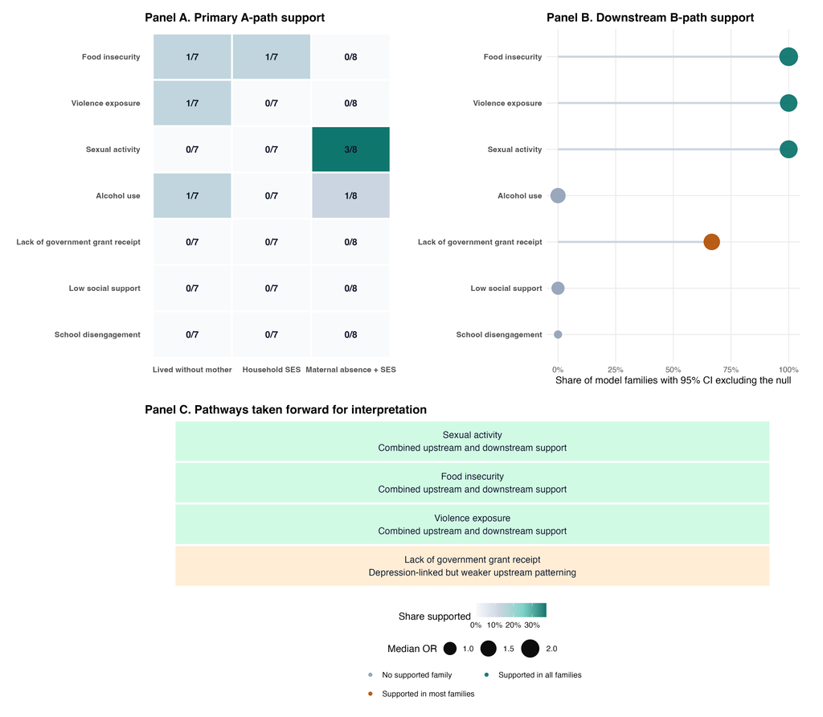

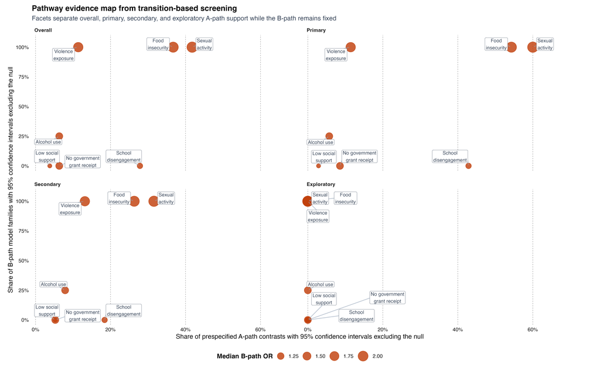

## 8 Pathway Coverage

| Variable | Pathway | Included in current screening | Scope note |
| --- | --- | --- | --- |
| DNKA | Alcohol use | TRUE | Included in current strict restricted trajectory model screening scope |
| ESXC | Ever had sexual intercourse | TRUE | Included in current strict restricted trajectory model screening scope |
| FDSC | Food insecurity | TRUE | Included in current strict restricted trajectory model screening scope |
| GOVG | Lack of government grant receipt | TRUE | Included in current strict restricted trajectory model screening scope |
| VLNC | Violence exposure | TRUE | Included in current strict restricted trajectory model screening scope |
| SCSP | Low social support | TRUE | Included in strict trajectory model screening via --include_school=true |
| SCHL | School disengagement | TRUE | Included in strict trajectory model screening via --include_school=true |

## 9 Upstream And Downstream Evidence

The upstream models ask whether childhood social-determinant histories are associated with each pathway domain. The downstream models ask whether the pathway domain remains associated with depressive symptoms after adjustment for exposure history and fixed contextual covariates.

| Model family | Pathway | Supported upstream contrasts |
| --- | --- | --- |
| Joint maternal absence and household socioeconomic status | Alcohol use | 1 |
| Household socioeconomic status | Alcohol use | 0 |
| Maternal co-residence | Alcohol use | 1 |
| Joint maternal absence and household socioeconomic status | Ever had sexual intercourse | 3 |
| Household socioeconomic status | Ever had sexual intercourse | 0 |
| Maternal co-residence | Ever had sexual intercourse | 0 |
| Joint maternal absence and household socioeconomic status | Food insecurity | 0 |
| Household socioeconomic status | Food insecurity | 1 |
| Maternal co-residence | Food insecurity | 1 |
| Joint maternal absence and household socioeconomic status | Lack of government grant receipt | 0 |
| Household socioeconomic status | Lack of government grant receipt | 0 |
| Maternal co-residence | Lack of government grant receipt | 0 |
| Joint maternal absence and household socioeconomic status | Low social support | 0 |
| Household socioeconomic status | Low social support | 0 |
| Maternal co-residence | Low social support | 0 |
| Joint maternal absence and household socioeconomic status | School disengagement | 0 |
| Household socioeconomic status | School disengagement | 0 |
| Maternal co-residence | School disengagement | 0 |
| Joint maternal absence and household socioeconomic status | Violence exposure | 0 |
| Household socioeconomic status | Violence exposure | 0 |
| Maternal co-residence | Violence exposure | 1 |

| Model family | Pathway | Supported downstream terms |
| --- | --- | --- |
| Joint maternal absence and household socioeconomic status | Alcohol use | 0 |
| Household socioeconomic status | Alcohol use | 0 |
| Maternal co-residence | Alcohol use | 0 |
| Joint maternal absence and household socioeconomic status | Ever had sexual intercourse | 1 |
| Household socioeconomic status | Ever had sexual intercourse | 1 |
| Maternal co-residence | Ever had sexual intercourse | 1 |
| Joint maternal absence and household socioeconomic status | Food insecurity | 1 |
| Household socioeconomic status | Food insecurity | 1 |
| Maternal co-residence | Food insecurity | 1 |
| Joint maternal absence and household socioeconomic status | Lack of government grant receipt | 1 |
| Household socioeconomic status | Lack of government grant receipt | 0 |
| Maternal co-residence | Lack of government grant receipt | 1 |
| Joint maternal absence and household socioeconomic status | Low social support | 0 |
| Household socioeconomic status | Low social support | 0 |
| Maternal co-residence | Low social support | 0 |
| Joint maternal absence and household socioeconomic status | School disengagement | 0 |
| Household socioeconomic status | School disengagement | 0 |
| Maternal co-residence | School disengagement | 0 |
| Joint maternal absence and household socioeconomic status | Violence exposure | 1 |
| Household socioeconomic status | Violence exposure | 1 |
| Maternal co-residence | Violence exposure | 1 |

### 9.1 Full Upstream Hypothesis Coefficients

| Model family | Pathway | Window | Hypothesis | Contrast | Expected direction | Supported | Odds ratio (95% CI) | p-value |
| --- | --- | --- | --- | --- | --- | --- | --- | --- |
| Maternal co-residence | Alcohol use | Early childhood | H1 | H1: Late-Onset Maternal Absence vs Stable Low Maternal Absence | higher | No | 1.140 (0.880, 1.476) | 0.321 |
| Maternal co-residence | Alcohol use | Early childhood | H1 | H1: Stable High Maternal Absence vs Stable Low Maternal Absence | higher | No | 1.246 (0.966, 1.606) | 0.090 |
| Maternal co-residence | Alcohol use | Early childhood | H1 | H1: Early Peak, Declining Maternal Absence vs Stable Low Maternal Absence | higher | No | 1.058 (0.849, 1.317) | 0.617 |
| Maternal co-residence | Alcohol use | Middle-late childhood | H1 | H1: Late-Onset Maternal Absence vs Stable Low Maternal Absence | higher | Yes | 1.388 (1.039, 1.854) | 0.026 |
| Maternal co-residence | Alcohol use | Middle-late childhood | H1 | H1: Mid-Childhood Onset Maternal Absence vs Stable Low Maternal Absence | higher | No | 1.131 (0.831, 1.538) | 0.434 |
| Maternal co-residence | Alcohol use | Middle-late childhood | H1 | H1: Declining Maternal Absence vs Stable Low Maternal Absence | higher | No | 1.181 (0.921, 1.514) | 0.189 |
| Maternal co-residence | Alcohol use | Middle-late childhood | H1 | H1: Stable High Maternal Absence vs Stable Low Maternal Absence | higher | No | 1.047 (0.838, 1.308) | 0.688 |
| Maternal co-residence | Ever had sexual intercourse | Early childhood | H1 | H1: Late-Onset Maternal Absence vs Stable Low Maternal Absence | higher | No | 1.018 (0.729, 1.420) | 0.918 |
| Maternal co-residence | Ever had sexual intercourse | Early childhood | H1 | H1: Stable High Maternal Absence vs Stable Low Maternal Absence | higher | No | 1.179 (0.862, 1.611) | 0.302 |
| Maternal co-residence | Ever had sexual intercourse | Early childhood | H1 | H1: Early Peak, Declining Maternal Absence vs Stable Low Maternal Absence | higher | No | 0.909 (0.694, 1.189) | 0.485 |
| Maternal co-residence | Ever had sexual intercourse | Middle-late childhood | H1 | H1: Late-Onset Maternal Absence vs Stable Low Maternal Absence | higher | No | 1.289 (0.919, 1.807) | 0.141 |
| Maternal co-residence | Ever had sexual intercourse | Middle-late childhood | H1 | H1: Mid-Childhood Onset Maternal Absence vs Stable Low Maternal Absence | higher | No | 0.949 (0.660, 1.363) | 0.775 |
| Maternal co-residence | Ever had sexual intercourse | Middle-late childhood | H1 | H1: Declining Maternal Absence vs Stable Low Maternal Absence | higher | No | 1.230 (0.894, 1.691) | 0.203 |
| Maternal co-residence | Ever had sexual intercourse | Middle-late childhood | H1 | H1: Stable High Maternal Absence vs Stable Low Maternal Absence | higher | No | 1.092 (0.830, 1.436) | 0.532 |
| Maternal co-residence | Food insecurity | Early childhood | H1 | H1: Late-Onset Maternal Absence vs Stable Low Maternal Absence | higher | No | 0.787 (0.601, 1.031) | 0.082 |
| Maternal co-residence | Food insecurity | Early childhood | H1 | H1: Stable High Maternal Absence vs Stable Low Maternal Absence | higher | No | 0.964 (0.738, 1.260) | 0.790 |
| Maternal co-residence | Food insecurity | Early childhood | H1 | H1: Early Peak, Declining Maternal Absence vs Stable Low Maternal Absence | higher | No | 0.954 (0.768, 1.185) | 0.669 |
| Maternal co-residence | Food insecurity | Middle-late childhood | H1 | H1: Late-Onset Maternal Absence vs Stable Low Maternal Absence | higher | No | 0.955 (0.713, 1.279) | 0.756 |
| Maternal co-residence | Food insecurity | Middle-late childhood | H1 | H1: Mid-Childhood Onset Maternal Absence vs Stable Low Maternal Absence | higher | No | 1.010 (0.746, 1.367) | 0.949 |
| Maternal co-residence | Food insecurity | Middle-late childhood | H1 | H1: Declining Maternal Absence vs Stable Low Maternal Absence | higher | Yes | 1.332 (1.037, 1.712) | 0.025 |
| Maternal co-residence | Food insecurity | Middle-late childhood | H1 | H1: Stable High Maternal Absence vs Stable Low Maternal Absence | higher | No | 1.068 (0.850, 1.341) | 0.571 |
| Maternal co-residence | Lack of government grant receipt | Early childhood | H1 | H1: Late-Onset Maternal Absence vs Stable Low Maternal Absence | higher | No | 1.076 (0.830, 1.396) | 0.580 |
| Maternal co-residence | Lack of government grant receipt | Early childhood | H1 | H1: Stable High Maternal Absence vs Stable Low Maternal Absence | higher | No | 1.160 (0.887, 1.518) | 0.279 |
| Maternal co-residence | Lack of government grant receipt | Early childhood | H1 | H1: Early Peak, Declining Maternal Absence vs Stable Low Maternal Absence | higher | No | 0.983 (0.786, 1.228) | 0.879 |
| Maternal co-residence | Lack of government grant receipt | Middle-late childhood | H1 | H1: Late-Onset Maternal Absence vs Stable Low Maternal Absence | higher | No | 0.860 (0.634, 1.167) | 0.333 |
| Maternal co-residence | Lack of government grant receipt | Middle-late childhood | H1 | H1: Mid-Childhood Onset Maternal Absence vs Stable Low Maternal Absence | higher | No | 0.877 (0.656, 1.174) | 0.378 |
| Maternal co-residence | Lack of government grant receipt | Middle-late childhood | H1 | H1: Declining Maternal Absence vs Stable Low Maternal Absence | higher | No | 1.099 (0.853, 1.415) | 0.467 |
| Maternal co-residence | Lack of government grant receipt | Middle-late childhood | H1 | H1: Stable High Maternal Absence vs Stable Low Maternal Absence | higher | No | 0.837 (0.667, 1.050) | 0.124 |
| Maternal co-residence | Violence exposure | Early childhood | H1 | H1: Late-Onset Maternal Absence vs Stable Low Maternal Absence | higher | No | 1.165 (0.900, 1.509) | 0.246 |
| Maternal co-residence | Violence exposure | Early childhood | H1 | H1: Stable High Maternal Absence vs Stable Low Maternal Absence | higher | Yes | 1.292 (1.001, 1.666) | 0.049 |

[output cut: 124 more lines]

### 9.2 Full Downstream Pathway Coefficients

| Model family | Effect type | Term | Odds ratio (95% CI) | p-value | N subjects | Pseudo rows |
| --- | --- | --- | --- | --- | --- | --- |
| Maternal co-residence | early_class | Early: Late-Onset Maternal Absence vs Stable Low Maternal Absence | 0.963 (0.547, 1.696) | 0.896 | 3,207 | 15,370 |
| Maternal co-residence | early_class | Early: Stable High Maternal Absence vs Stable Low Maternal Absence | 1.427 (0.839, 2.428) | 0.189 | 3,207 | 15,370 |
| Maternal co-residence | early_class | Early: Early Peak, Declining Maternal Absence vs Stable Low Maternal Absence | 1.168 (0.742, 1.839) | 0.501 | 3,207 | 15,370 |
| Maternal co-residence | mid_class | Middle-late: Late-Onset Maternal Absence vs Stable Low Maternal Absence | 1.041 (0.575, 1.885) | 0.895 | 3,207 | 15,370 |
| Maternal co-residence | mid_class | Middle-late: Mid-Childhood Onset Maternal Absence vs Stable Low Maternal Absence | 1.329 (0.712, 2.478) | 0.372 | 3,207 | 15,370 |
| Maternal co-residence | mid_class | Middle-late: Declining Maternal Absence vs Stable Low Maternal Absence | 1.023 (0.596, 1.755) | 0.934 | 3,207 | 15,370 |
| Maternal co-residence | mid_class | Middle-late: Stable High Maternal Absence vs Stable Low Maternal Absence | 1.162 (0.726, 1.860) | 0.532 | 3,207 | 15,370 |
| Maternal co-residence | mediator | Alcohol use | 1.330 (0.912, 1.939) | 0.139 | 3,207 | 15,370 |
| Maternal co-residence | mediator | Ever had sexual intercourse | 1.916 (1.193, 3.078) | 0.007 | 3,207 | 15,370 |
| Maternal co-residence | mediator | Food insecurity | 2.062 (1.468, 2.897) | 0.000 | 3,207 | 15,370 |
| Maternal co-residence | mediator | Lack of government grant receipt | 1.479 (1.001, 2.186) | 0.049 | 3,207 | 15,370 |
| Maternal co-residence | mediator | Violence exposure | 1.822 (1.282, 2.589) | 0.001 | 3,207 | 15,370 |
| Maternal co-residence | mediator | Low social support | 0.990 (0.550, 1.784) | 0.973 | 3,207 | 15,370 |
| Maternal co-residence | mediator | School disengagement | 0.684 (0.420, 1.114) | 0.127 | 3,207 | 15,370 |
| Household socioeconomic status | early_class | Early: Chronic Low SES vs Stable Higher SES | 0.454 (0.113, 1.817) | 0.265 | 1,523 | 12,386 |
| Household socioeconomic status | early_class | Early: Improving from Low SES vs Stable Higher SES | 0.910 (0.266, 3.121) | 0.881 | 1,523 | 12,386 |
| Household socioeconomic status | early_class | Early: Late Improvement from Chronic Low SES vs Stable Higher SES | 0.643 (0.164, 2.516) | 0.526 | 1,523 | 12,386 |
| Household socioeconomic status | mid_class | Middle-late: Late Improvement from Chronic Low SES vs Stable Higher SES | 1.809 (0.727, 4.499) | 0.202 | 1,523 | 12,386 |
| Household socioeconomic status | mid_class | Middle-late: Persistent Moderate Low SES vs Stable Higher SES | 1.417 (0.504, 3.978) | 0.509 | 1,523 | 12,386 |
| Household socioeconomic status | mid_class | Middle-late: Early Improvement from Mild Low SES vs Stable Higher SES | 1.400 (0.687, 2.852) | 0.354 | 1,523 | 12,386 |
| Household socioeconomic status | mid_class | Middle-late: Chronic Low SES vs Stable Higher SES | 2.598 (0.990, 6.818) | 0.052 | 1,523 | 12,386 |
| Household socioeconomic status | mediator | Alcohol use | 0.931 (0.470, 1.847) | 0.838 | 1,523 | 12,386 |
| Household socioeconomic status | mediator | Ever had sexual intercourse | 2.310 (1.064, 5.012) | 0.034 | 1,523 | 12,386 |
| Household socioeconomic status | mediator | Food insecurity | 3.052 (1.693, 5.503) | 0.000 | 1,523 | 12,386 |
| Household socioeconomic status | mediator | Lack of government grant receipt | 1.869 (0.952, 3.669) | 0.069 | 1,523 | 12,386 |
| Household socioeconomic status | mediator | Violence exposure | 1.933 (1.022, 3.658) | 0.043 | 1,523 | 12,386 |
| Household socioeconomic status | mediator | Low social support | 1.802 (0.752, 4.314) | 0.186 | 1,523 | 12,386 |
| Household socioeconomic status | mediator | School disengagement | 0.530 (0.164, 1.715) | 0.290 | 1,523 | 12,386 |
| Joint maternal absence and household socioeconomic status | early_class | Early: Rising Maternal Absence, Low SES vs Low Maternal Absence, Improving SES | 0.879 (0.511, 1.512) | 0.640 | 3,391 | 30,537 |
| Joint maternal absence and household socioeconomic status | early_class | Early: Low Maternal Absence, Low SES vs Low Maternal Absence, Improving SES | 0.564 (0.298, 1.070) | 0.080 | 3,391 | 30,537 |
| Joint maternal absence and household socioeconomic status | early_class | Early: High Maternal Absence, Low SES vs Low Maternal Absence, Improving SES | 0.607 (0.358, 1.028) | 0.063 | 3,391 | 30,537 |
| Joint maternal absence and household socioeconomic status | early_class | Early: Rising Maternal Absence, Improving SES vs Low Maternal Absence, Improving SES | 0.657 (0.385, 1.120) | 0.123 | 3,391 | 30,537 |
| Joint maternal absence and household socioeconomic status | mid_class | Middle-late: Rising Maternal Absence, Improving SES vs Low Maternal Absence, Higher SES | 0.703 (0.363, 1.361) | 0.295 | 3,391 | 30,537 |
| Joint maternal absence and household socioeconomic status | mid_class | Middle-late: Low Maternal Absence, Low SES vs Low Maternal Absence, Higher SES | 0.755 (0.495, 1.151) | 0.191 | 3,391 | 30,537 |
| Joint maternal absence and household socioeconomic status | mid_class | Middle-late: High Maternal Absence, Improving SES vs Low Maternal Absence, Higher SES | 1.031 (0.635, 1.673) | 0.902 | 3,391 | 30,537 |
| Joint maternal absence and household socioeconomic status | mid_class | Middle-late: Decreasing Maternal Absence, Low SES vs Low Maternal Absence, Higher SES | 0.982 (0.536, 1.800) | 0.954 | 3,391 | 30,537 |
| Joint maternal absence and household socioeconomic status | mid_class | Middle-late: High Maternal Absence, Low SES vs Low Maternal Absence, Higher SES | 1.080 (0.623, 1.873) | 0.783 | 3,391 | 30,537 |
| Joint maternal absence and household socioeconomic status | mid_class | Middle-late: Low Maternal Absence, Improving SES vs Low Maternal Absence, Higher SES | 0.983 (0.586, 1.650) | 0.948 | 3,391 | 30,537 |
| Joint maternal absence and household socioeconomic status | mediator | Alcohol use | 1.347 (0.933, 1.945) | 0.111 | 3,391 | 30,537 |
| Joint maternal absence and household socioeconomic status | mediator | Ever had sexual intercourse | 1.784 (1.125, 2.828) | 0.014 | 3,391 | 30,537 |
| Joint maternal absence and household socioeconomic status | mediator | Food insecurity | 2.123 (1.523, 2.959) | 0.000 | 3,391 | 30,537 |
| Joint maternal absence and household socioeconomic status | mediator | Lack of government grant receipt | 1.572 (1.074, 2.300) | 0.020 | 3,391 | 30,537 |
| Joint maternal absence and household socioeconomic status | mediator | Violence exposure | 1.734 (1.236, 2.432) | 0.001 | 3,391 | 30,537 |
| Joint maternal absence and household socioeconomic status | mediator | Low social support | 0.970 (0.550, 1.712) | 0.916 | 3,391 | 30,537 |
| Joint maternal absence and household socioeconomic status | mediator | School disengagement | 0.674 (0.418, 1.086) | 0.105 | 3,391 | 30,537 |

## 10 Fixed-Covariate Sensitivity Drivers

| Model family | Pathway | Strongest attenuation driver | Attenuation step |
| --- | --- | --- | --- |
| Joint maternal absence and household socioeconomic status | Alcohol use | Age added | 0.035 |
| Joint maternal absence and household socioeconomic status | Ever had sexual intercourse | Age added | 0.249 |
| Joint maternal absence and household socioeconomic status | Food insecurity | Age added | 0.008 |
| Joint maternal absence and household socioeconomic status | Lack of government grant receipt | Age added | 0.085 |
| Joint maternal absence and household socioeconomic status | Low social support | Calendar year added | 0.023 |
| Joint maternal absence and household socioeconomic status | School disengagement | Age added | 0.019 |
| Joint maternal absence and household socioeconomic status | Violence exposure | Calendar year added | 0.056 |
| Household socioeconomic status | Alcohol use | Age added | 0.008 |
| Household socioeconomic status | Ever had sexual intercourse | Age added | 0.038 |
| Household socioeconomic status | Food insecurity | Age added | 0.004 |
| Household socioeconomic status | Lack of government grant receipt | Age added | 0.017 |
| Household socioeconomic status | Low social support | Rural added | 0.012 |
| Household socioeconomic status | School disengagement | Calendar year added | 0.001 |
| Household socioeconomic status | Violence exposure | Calendar year added | 0.001 |
| Maternal co-residence | Alcohol use | Age added | 0.033 |
| Maternal co-residence | Ever had sexual intercourse | Age added | 0.265 |
| Maternal co-residence | Food insecurity | Age added | 0.014 |
| Maternal co-residence | Lack of government grant receipt | Age added | 0.097 |
| Maternal co-residence | Low social support | Calendar year added | 0.069 |
| Maternal co-residence | School disengagement | Calendar year added | 0.000 |
| Maternal co-residence | Violence exposure | Calendar year added | 0.056 |

| Model family | Pathway | Adjustment set | Odds ratio | p-value | Attenuation | Significant |
| --- | --- | --- | --- | --- | --- | --- |
| Joint maternal absence and household socioeconomic status | Alcohol use | Sex only | 1.325 | 0.061 | Starting model | No |
| Joint maternal absence and household socioeconomic status | Alcohol use | Sex + age | 1.280 | 0.103 | 12% reduction in \|log(OR)\| | No |
| Joint maternal absence and household socioeconomic status | Alcohol use | Sex + age + rural | 1.277 | 0.105 | 1% reduction in \|log(OR)\| | No |
| Joint maternal absence and household socioeconomic status | Alcohol use | Sex + age + rural + calendar year | 1.318 | 0.075 | 13% increase in \|log(OR)\| | No |
| Joint maternal absence and household socioeconomic status | Ever had sexual intercourse | Sex only | 2.181 | 0.000 | Starting model | Yes |
| Joint maternal absence and household socioeconomic status | Ever had sexual intercourse | Sex + age | 1.701 | 0.009 | 32% reduction in \|log(OR)\| | Yes |
| Joint maternal absence and household socioeconomic status | Ever had sexual intercourse | Sex + age + rural | 1.686 | 0.010 | 2% reduction in \|log(OR)\| | Yes |
| Joint maternal absence and household socioeconomic status | Ever had sexual intercourse | Sex + age + rural + calendar year | 1.635 | 0.016 | 6% reduction in \|log(OR)\| | Yes |
| Joint maternal absence and household socioeconomic status | Food insecurity | Sex only | 2.001 | 0.000 | Starting model | Yes |
| Joint maternal absence and household socioeconomic status | Food insecurity | Sex + age | 1.986 | 0.000 | 1% reduction in \|log(OR)\| | Yes |
| Joint maternal absence and household socioeconomic status | Food insecurity | Sex + age + rural | 1.972 | 0.000 | 1% reduction in \|log(OR)\| | Yes |
| Joint maternal absence and household socioeconomic status | Food insecurity | Sex + age + rural + calendar year | 1.985 | 0.000 | 1% increase in \|log(OR)\| | Yes |
| Joint maternal absence and household socioeconomic status | Lack of government grant receipt | Sex only | 1.276 | 0.116 | Starting model | No |
| Joint maternal absence and household socioeconomic status | Lack of government grant receipt | Sex + age | 1.172 | 0.306 | 35% reduction in \|log(OR)\| | No |
| Joint maternal absence and household socioeconomic status | Lack of government grant receipt | Sex + age + rural | 1.159 | 0.344 | 7% reduction in \|log(OR)\| | No |
| Joint maternal absence and household socioeconomic status | Lack of government grant receipt | Sex + age + rural + calendar year | 1.142 | 0.397 | 10% reduction in \|log(OR)\| | No |
| Joint maternal absence and household socioeconomic status | Low social support | Sex only | 1.012 | 0.959 | Starting model | No |
| Joint maternal absence and household socioeconomic status | Low social support | Sex + age | 0.965 | 0.878 | 205% increase in \|log(OR)\| | No |
| Joint maternal absence and household socioeconomic status | Low social support | Sex + age + rural | 0.955 | 0.843 | 30% increase in \|log(OR)\| | No |
| Joint maternal absence and household socioeconomic status | Low social support | Sex + age + rural + calendar year | 1.024 | 0.921 | 49% reduction in \|log(OR)\| | No |
| Joint maternal absence and household socioeconomic status | School disengagement | Sex only | 1.145 | 0.418 | Starting model | No |
| Joint maternal absence and household socioeconomic status | School disengagement | Sex + age | 0.890 | 0.520 | 14% reduction in \|log(OR)\| | No |
| Joint maternal absence and household socioeconomic status | School disengagement | Sex + age + rural | 0.878 | 0.476 | 12% increase in \|log(OR)\| | No |
| Joint maternal absence and household socioeconomic status | School disengagement | Sex + age + rural + calendar year | 0.879 | 0.475 | 1% reduction in \|log(OR)\| | No |
| Joint maternal absence and household socioeconomic status | Violence exposure | Sex only | 1.868 | 0.000 | Starting model | Yes |
| Joint maternal absence and household socioeconomic status | Violence exposure | Sex + age | 1.958 | 0.000 | 7% increase in \|log(OR)\| | Yes |
| Joint maternal absence and household socioeconomic status | Violence exposure | Sex + age + rural | 1.951 | 0.000 | 1% reduction in \|log(OR)\| | Yes |
| Joint maternal absence and household socioeconomic status | Violence exposure | Sex + age + rural + calendar year | 1.844 | 0.000 | 8% reduction in \|log(OR)\| | Yes |
| Joint parental residence and household socioeconomic status | Alcohol use | Sex only | 1.278 | 0.100 | Starting model | No |
| Joint parental residence and household socioeconomic status | Alcohol use | Sex + age | 1.230 | 0.168 | 16% reduction in \|log(OR)\| | No |

[output cut: 82 more lines]

| Model family | Adjustment set | Maximum VIF |
| --- | --- | --- |
| Joint maternal absence and household socioeconomic status | Sex + age | 1.204 |
| Joint parental residence and household socioeconomic status | Sex + age | 1.209 |
| Household socioeconomic status | Sex + age | 1.517 |
| Maternal co-residence | Sex + age | 1.192 |
| Joint maternal absence and household socioeconomic status | Sex + age + rural | 1.204 |
| Joint parental residence and household socioeconomic status | Sex + age + rural | 1.209 |
| Household socioeconomic status | Sex + age + rural | 1.517 |
| Maternal co-residence | Sex + age + rural | 1.192 |
| Joint maternal absence and household socioeconomic status | Sex + age + rural + calendar year | 1.204 |
| Joint parental residence and household socioeconomic status | Sex + age + rural + calendar year | 1.209 |
| Household socioeconomic status | Sex + age + rural + calendar year | 1.517 |
| Maternal co-residence | Sex + age + rural + calendar year | 1.192 |
| Joint maternal absence and household socioeconomic status | Sex only | 1.204 |
| Joint parental residence and household socioeconomic status | Sex only | 1.209 |
| Household socioeconomic status | Sex only | 1.517 |
| Maternal co-residence | Sex only | 1.192 |

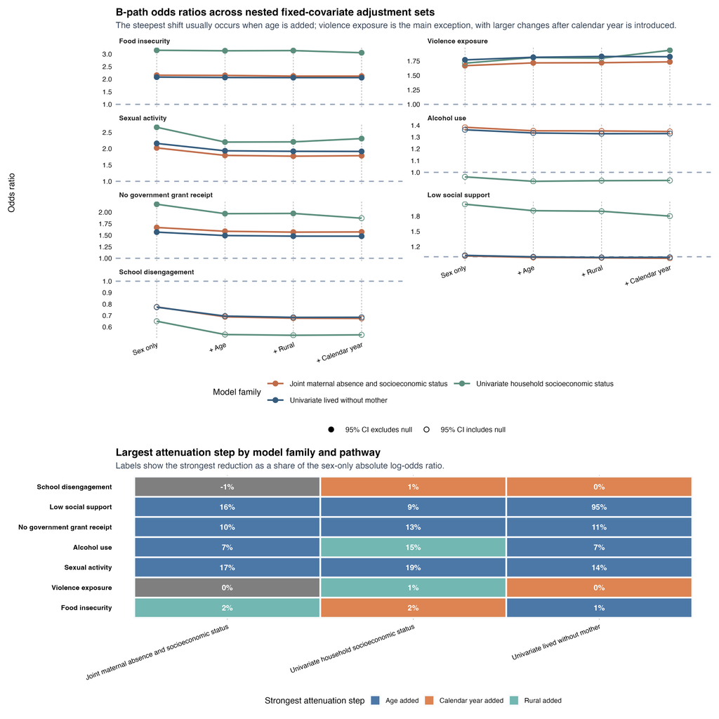

## 11 Two-Window Maternal Co-Residence Sensitivity

| Pathway | Primary A-path, 0-5 years | Primary A-path, 6-12 years | Primary B-path | Two-window BCH range | Comparison summary |
| --- | --- | --- | --- | --- | --- |
| Alcohol use | Stable Low Maternal Absence; vs; Late-Onset Maternal Absence; OR 0.65 to 1.14; p=0.296 | Late-Onset Maternal Absence; vs; Stable High Maternal Absence; OR 0.82 to 1.72; p=0.357 | OR 1.00 to 1.84; p=0.049; significant=Yes | 0.140 to 0.866; range=0.726; significant RD pairs=6 | Primary B-path is positive and BCH shows joint-pattern separation, but window-specific A-path estimates remain weak. |
| No government grant receipt | Stable High Maternal Absence; vs; Late-Onset Maternal Absence; OR 0.76 to 1.57; p=0.639 | Declining Maternal Absence; vs; Stable High Maternal Absence; OR 0.87 to 1.65; p=0.275 | OR 0.81 to 1.52; p=0.514; significant=No | 0.015 to 0.685; range=0.670; significant RD pairs=9 | BCH shows joint-pattern heterogeneity, but the pathway is not yet associated with depressive symptoms in the primary B-path screen. |
| Violence exposure | Stable Low Maternal Absence; vs; Late-Onset Maternal Absence; OR 0.70 to 1.23; p=0.584 | Stable Low Maternal Absence; vs; Stable High Maternal Absence; OR 0.90 to 1.42; p=0.304 | OR 1.39 to 2.49; p=0.000; significant=Yes | 0.484 to 1.000; range=0.516; significant RD pairs=18 | Primary B-path is positive and BCH shows joint-pattern separation, but window-specific A-path estimates remain weak. |
| Food insecurity | Stable Low Maternal Absence; vs; Late-Onset Maternal Absence; OR 0.96 to 1.78; p=0.086 | Declining Maternal Absence; vs; Stable High Maternal Absence; OR 0.93 to 1.75; p=0.136 | OR 1.55 to 2.73; p=0.000; significant=Yes | 0.513 to 1.000; range=0.487; significant RD pairs=19 | Primary B-path is positive and BCH shows joint-pattern separation, but window-specific A-path estimates remain weak. |
| Ever had sexual intercourse | Stable High Maternal Absence; vs; Late-Onset Maternal Absence; OR 0.75 to 1.85; p=0.482 | Mid-Childhood Onset Maternal Absence; vs; Stable High Maternal Absence; OR 0.45 to 1.10; p=0.121 | OR 1.07 to 2.25; p=0.021; significant=Yes | 0.000 to 0.082; range=0.082; significant RD pairs=45 | Primary B-path is positive and BCH shows joint-pattern separation, but window-specific A-path estimates remain weak. |

|  | Metric | Value |
| --- | --- | --- |
| mediator | mediator | DNKA; GOVG; VLNC; FDSC; ESXC |
| mediator_label | mediator_label | Alcohol use; No government grant receipt; Violence exposure; Food insecurity; Ever had sexual intercourse |
| primary_best_contrast_early | primary_best_contrast_early | Stable Low Maternal Absence vs Late-Onset Maternal Absence; Stable High Maternal Absence vs Late-Onset Maternal Absence |
| primary_best_contrast_mid | primary_best_contrast_mid | Late-Onset Maternal Absence vs Stable High Maternal Absence; Declining Maternal Absence vs Stable High Maternal Absence; Stable Low Maternal Absence vs Stable High Maternal Absence; Mid-Childhood Onse… |
| primary_best_or_early | primary_best_or_early | 0.861258575679661; 1.09043077948124; 0.923752558996752; 1.30901160782895; 1.17629977494346 |
| primary_best_or_mid | primary_best_or_mid | 1.18862098407492; 1.19655191389279; 1.12691847217435; 1.27340030264753; 0.700978721598489 |
| primary_best_or_ci_early | primary_best_or_ci_early | 0.65 to 1.14; 0.76 to 1.57; 0.70 to 1.23; 0.96 to 1.78; 0.75 to 1.85 |
| primary_best_or_ci_mid | primary_best_or_ci_mid | 0.82 to 1.72; 0.87 to 1.65; 0.90 to 1.42; 0.93 to 1.75; 0.45 to 1.10 |
| primary_best_p_early | primary_best_p_early | 0.296183026330984; 0.638661821245646; 0.584341404780281; 0.0858733280919566; 0.481984798101872 |
| primary_best_p_mid | primary_best_p_mid | 0.357300447034975; 0.274879559261791; 0.303648602826675; 0.135875258362038; 0.121443055208709 |
| primary_any_sig_early | primary_any_sig_early | No |
| primary_any_sig_mid | primary_any_sig_mid | No |
| b_path_or | b_path_or | 1.35787931350224; 1.11049975944348; 1.85708494265254; 2.05537258459236; 1.55038228013001 |
| b_path_or_ci | b_path_or_ci | 1.00 to 1.84; 0.81 to 1.52; 1.39 to 2.49; 1.55 to 2.73; 1.07 to 2.25 |
| b_path_p | b_path_p | 0.0485061591166585; 0.513841453364126; 3.14818995141852e-05; 6.00684574525445e-07; 0.0211464730237276 |
| b_path_sig | b_path_sig | Yes; No |
| bch_lowest_pattern | bch_lowest_pattern | Stable High Maternal Absence -> Mid-Childhood Onset Maternal Absence; Stable High Maternal Absence -> Late-Onset Maternal Absence; Stable High Maternal Absence -> Stable Low Maternal Absence; Early Pe… |
| bch_min_prob | bch_min_prob | 0.14; 0.015; 0.484; 0.513; 0 |
| bch_highest_pattern | bch_highest_pattern | Late-Onset Maternal Absence -> Mid-Childhood Onset Maternal Absence; Early Peak, Declining Maternal Absence -> Mid-Childhood Onset Maternal Absence; Stable High Maternal Absence -> Late-Onset Maternal… |
| bch_max_prob | bch_max_prob | 0.866; 0.685; 1; 0.082 |
| bch_prob_range | bch_prob_range | 0.726; 0.67; 0.516; 0.487; 0.082 |
| bch_sig_rd_pairs | bch_sig_rd_pairs | 6; 9; 18; 19; 45 |
| bch_min_rd | bch_min_rd | -0.726; -0.531; -0.463; -0.487; -0.082 |
| bch_max_rd | bch_max_rd | 0.721; 0.67; 0.516; 0.289; 0.066 |
| comparison_note | comparison_note | Primary B-path is positive and BCH shows joint-pattern separation, but window-specific A-path estimates remain weak.; BCH shows joint-pattern heterogeneity, but the pathway is not yet associated with … |

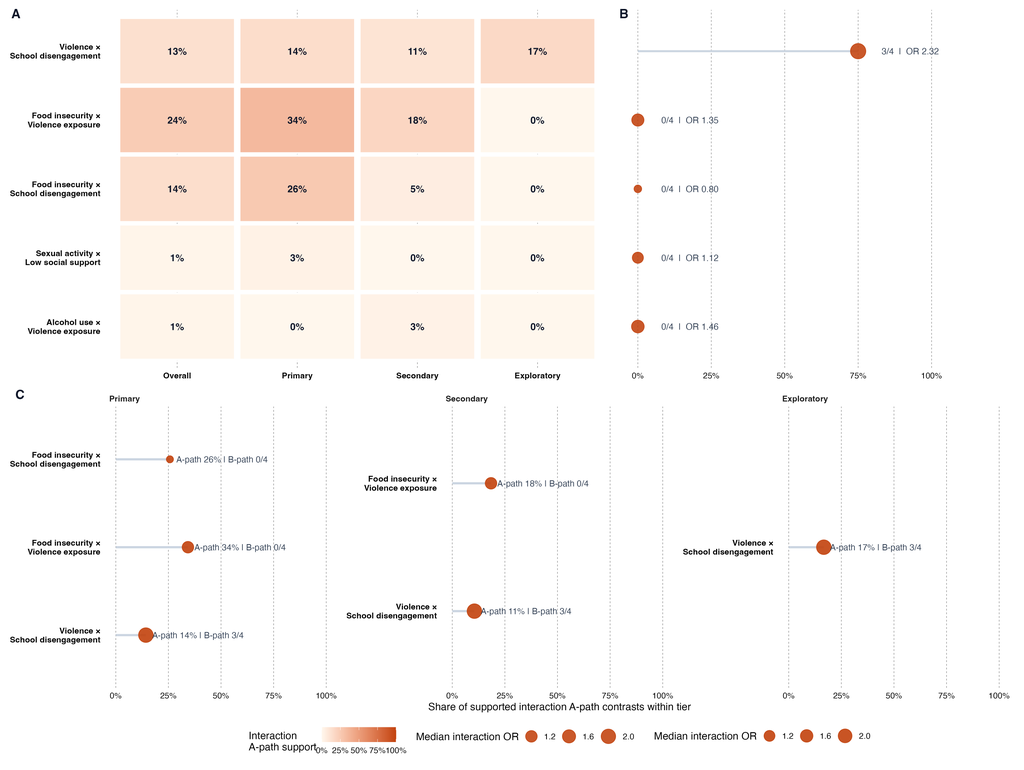

## 12 Analytical Decision

The current Objective 4 decision is:

- carry food insecurity forward as the clearest candidate pathway;
- retain violence exposure as a central pathway domain;
- retain ever having had sexual intercourse as a supporting pathway marker;
- keep alcohol use and lack of government grant receipt visible as extended or cautious domains;
- treat low social support and school disengagement as reported screened domains but not as core mediators for Objective 5;
- preserve the full pathway inventory because several youth-generated pathway domains remain outside the measurable secondary-data block.

## 13 Website Consistency Check

The Objective 4 website page is consistent with this analytical report if it uses the 25 May 2026 pathway-screening figures, describes food insecurity and violence exposure as the strongest retained domains, keeps sexual activity as supporting evidence, and avoids presenting the older April pathway figure as the current source of truth.